# Course Project

Andrea Di Iura

## Course Project

### Load data

We load data from the directory `data`.

```r
training_name = "data/pml-training.csv"
testing_name = "data/pml-testing.csv"

training = read.csv(training_name, na.strings=c("", "NA", "#DIV/0!"))
testing = read.csv(testing_name, na.strings=c("", "NA", "#DIV/0!"))
```

Using the commands `head`, `str` and `summary` we investigate the training dataset, the output is quite long thus we do not show it here. The datasets dimensions are

```r
dim(training)
```

```
## [1] 19622   160
```

```r
dim(testing)
```

```
## [1]  20 160
```

We can reduce the number of columns in the training dataset because the first column contains the indeces. We also remove the columns with at least one NA values or columns with near zero variance variables using the function `nearZeroVar` contained in the `caret` library. Also the variables $1\div6$ can be neglected. To do this we create a mask variable called `mask_training`.

```r
training$X = NULL
testing$X = NULL
```

```r
library(caret)
NZV = nearZeroVar(training, saveMetrics= TRUE)
mask_training = !(colSums(is.na(training)) > 0) & !NZV$nzv

training_small = training[,mask_training]
testing_small = testing[,mask_training]

training_small = training_small[,-c(1:6)]
testing_small = testing_small[,-c(1:6)]
```

We reduce the dimensions

```r
dim(training_small)
```

```
## [1] 19622    52
```

```r
dim(testing_small)
```

```
## [1] 20 52
```

The training and the validation datasets can be created using the `caret` function `createDataPartition`. For reproducability we also set seed

```r
set.seed(1234)


inTrain = createDataPartition(y = training_small$classe, p = 0.6, list = FALSE)
train = training_small[inTrain,]
valid = training_small[-inTrain,]
```

```r
dim(train)
```

```
## [1] 11776    52
```

```r
dim(valid)
```

```
## [1] 7846   52
```

## Exploratory analysis

A first step is to perform some exploratory analysis to show possible correlations among the variables. We use the `corrplot` package to see all the possible correlations in the dataset.

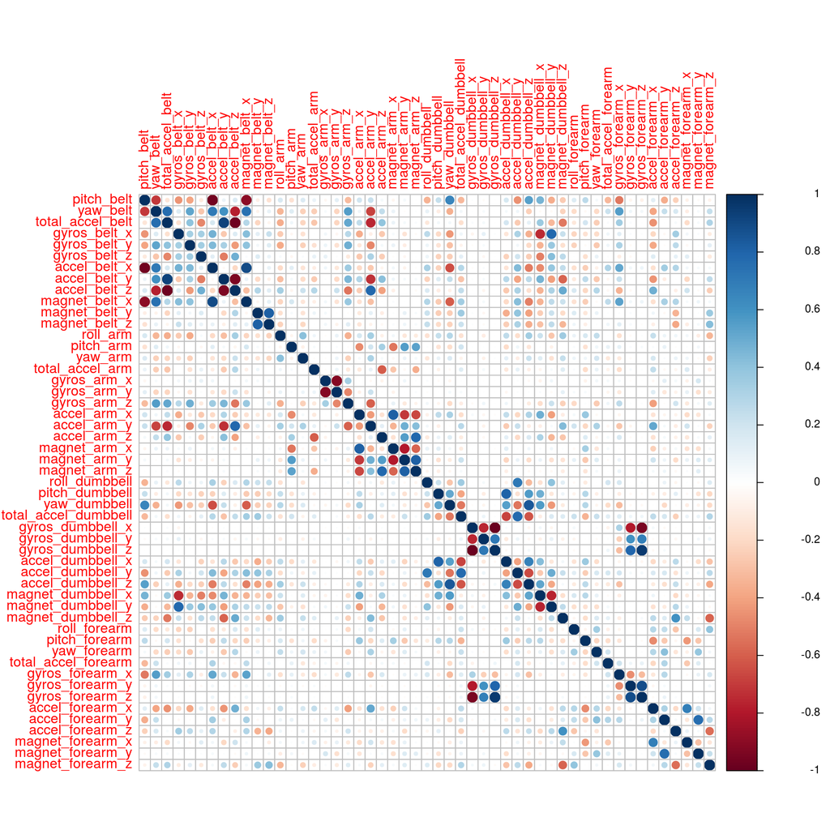

```r
library(corrplot)

MCorr = cor(train[,-dim(train)[2]])
corrplot(MCorr, cl.ratio=0.2, cl.align="r")
```

We could omit highly correlated variables, over correlation of 0.75

```r
HighCorr =  findCorrelation(MCorr, cutoff =  0.75)
# Subset data with our correlation limit
train = train[-HighCorr]
valid = valid[-HighCorr]

testing_small = testing_small[-HighCorr]
```

Thus we can reduce the dimensions

```r
dim(train)
```

```
## [1] 11776    32
```

```r
dim(valid)
```

```
## [1] 7846   32
```

## Machine Learning Analysis

To construct an accurate model we combine 4 different alghoritms: Supported Vector Machines (SVM), Linear Discriminant Analysis (LDA), Random Forest (RF) and Gradient Boosted Methods (GBM). With the `caret` package we evaluate the models on the `train` dataset

```r
control_method  =  trainControl(method = 'cv', number =  5)

mod_svm = train(classe ~ ., data = train, method = "svmLinear", trControl = control_method, verbose = FALSE)
mod_lda = train(classe ~ ., data = train, method = "lda", verbose = FALSE)
mod_rf = train(classe ~ ., data = train, method = "rf", trControl = control_method, verbose = FALSE)
mod_gbm = train(classe ~ ., data = train, method = "gbm", trControl = control_method, verbose = FALSE)
```

The confusion matrices for the models considered above using the `valid` datasets are

```r
cat("############\n
SVM - method\n
############\n")
```

```
## ############
##
## SVM - method
##
## ############
```

```r
prediction_svm = predict(mod_svm, valid)
confusionMatrix(prediction_svm, valid$classe)
```

```
## Confusion Matrix and Statistics
##
##           Reference
## Prediction    A    B    C    D    E
##          A 1817  360  228  160  129
##          B  119  808  141  100  260
##          C  167  141  858  162  175
##          D   91   96  107  763  141
##          E   38  113   34  101  737
##
## Overall Statistics
##
##                Accuracy : 0.6351
##                  95% CI : (0.6243, 0.6458)
##     No Information Rate : 0.2845
##     P-Value [Acc > NIR] : < 2.2e-16
##
##                   Kappa : 0.535
##  Mcnemar's Test P-Value : < 2.2e-16
##
## Statistics by Class:
##
##                      Class: A Class: B Class: C Class: D Class: E
## Sensitivity            0.8141   0.5323   0.6272  0.59331  0.51110
## Specificity            0.8438   0.9020   0.9004  0.93369  0.95534
## Pos Pred Value         0.6745   0.5658   0.5709  0.63689  0.72043
## Neg Pred Value         0.9194   0.8894   0.9196  0.92133  0.89667
## Prevalence             0.2845   0.1935   0.1744  0.16391  0.18379
## Detection Rate         0.2316   0.1030   0.1094  0.09725  0.09393
## Detection Prevalence   0.3434   0.1820   0.1916  0.15269  0.13038
## Balanced Accuracy      0.8289   0.7172   0.7638  0.76350  0.73322
```

```r
cat("############\n
LDA - method\n
############\n")
```

```
## ############
##
## LDA - method
##
## ############
```

```r
prediction_lda = predict(mod_lda, valid)
confusionMatrix(prediction_lda, valid$classe)
```

```
## Confusion Matrix and Statistics
##
##           Reference
## Prediction    A    B    C    D    E
##          A 1559  344  184   76  101
##          B  236  723  133  132  264
##          C  234  187  854  177  206
##          D  153  142  153  771  186
##          E   50  122   44  130  685
##
## Overall Statistics
##
##                Accuracy : 0.5853
##                  95% CI : (0.5743, 0.5962)
##     No Information Rate : 0.2845
##     P-Value [Acc > NIR] : < 2.2e-16
##
##                   Kappa : 0.4756
##  Mcnemar's Test P-Value : < 2.2e-16
##
## Statistics by Class:
##
##                      Class: A Class: B Class: C Class: D Class: E
## Sensitivity            0.6985  0.47628   0.6243  0.59953  0.47503
## Specificity            0.8744  0.87911   0.8759  0.90335  0.94597
## Pos Pred Value         0.6886  0.48589   0.5151  0.54875  0.66440
## Neg Pred Value         0.8794  0.87496   0.9169  0.92004  0.88892
## Prevalence             0.2845  0.19347   0.1744  0.16391  0.18379
## Detection Rate         0.1987  0.09215   0.1088  0.09827  0.08731
## Detection Prevalence   0.2886  0.18965   0.2113  0.17907  0.13140
## Balanced Accuracy      0.7864  0.67770   0.7501  0.75144  0.71050
```

```r
cat("###########\n
RF - method\n
###########\n")
```

```
## ###########
##
## RF - method
##
## ###########
```

```r
prediction_rf = predict(mod_rf, valid)
confusionMatrix(prediction_rf, valid$classe)
```

```
## Confusion Matrix and Statistics
##
##           Reference
## Prediction    A    B    C    D    E
##          A 2232   28    1    0    0
##          B    0 1480   14    0    0
##          C    0    8 1341   34    4
##          D    0    2   12 1250    3
##          E    0    0    0    2 1435
##
## Overall Statistics
##
##                Accuracy : 0.9862
##                  95% CI : (0.9834, 0.9887)
##     No Information Rate : 0.2845
##     P-Value [Acc > NIR] : < 2.2e-16
##
##                   Kappa : 0.9826
##  Mcnemar's Test P-Value : NA
##
## Statistics by Class:
##
##                      Class: A Class: B Class: C Class: D Class: E
## Sensitivity            1.0000   0.9750   0.9803   0.9720   0.9951
## Specificity            0.9948   0.9978   0.9929   0.9974   0.9997
## Pos Pred Value         0.9872   0.9906   0.9668   0.9866   0.9986
## Neg Pred Value         1.0000   0.9940   0.9958   0.9945   0.9989
## Prevalence             0.2845   0.1935   0.1744   0.1639   0.1838
## Detection Rate         0.2845   0.1886   0.1709   0.1593   0.1829
## Detection Prevalence   0.2882   0.1904   0.1768   0.1615   0.1832
## Balanced Accuracy      0.9974   0.9864   0.9866   0.9847   0.9974
```

```r
cat("############\n
GBM - method\n
############\n")
```

```
## ############
##
## GBM - method
##
## ############
```

```r
prediction_gbm = predict(mod_gbm, valid)
confusionMatrix(prediction_gbm, valid$classe)
```

```
## Confusion Matrix and Statistics
##
##           Reference
## Prediction    A    B    C    D    E
##          A 2157   97    9    9   10
##          B   21 1304   83   19   61
##          C   19  102 1225   77   38
##          D   31    8   48 1165   32
##          E    4    7    3   16 1301
##
## Overall Statistics
##
##                Accuracy : 0.9115
##                  95% CI : (0.905, 0.9177)
##     No Information Rate : 0.2845
##     P-Value [Acc > NIR] : < 2.2e-16
##
##                   Kappa : 0.888
##  Mcnemar's Test P-Value : < 2.2e-16
##
## Statistics by Class:
##
##                      Class: A Class: B Class: C Class: D Class: E
## Sensitivity            0.9664   0.8590   0.8955   0.9059   0.9022
## Specificity            0.9777   0.9709   0.9636   0.9819   0.9953
## Pos Pred Value         0.9452   0.8763   0.8385   0.9073   0.9775
## Neg Pred Value         0.9865   0.9663   0.9776   0.9816   0.9784
## Prevalence             0.2845   0.1935   0.1744   0.1639   0.1838
## Detection Rate         0.2749   0.1662   0.1561   0.1485   0.1658
## Detection Prevalence   0.2908   0.1897   0.1862   0.1637   0.1696
## Balanced Accuracy      0.9721   0.9150   0.9295   0.9439   0.9488
```

We can create a combined dataframe to improve our predictions. We use a Random Forest model to construct the final model `model_combined`.

```r
combined_df = data.frame(prediction_svm, prediction_lda, prediction_rf, prediction_gbm, classe = valid$classe)
model_combined = train(classe ~ ., method = "rf", data = combined_df, verbose = FALSE)
```

The results of the combined fit are

```r
prediction_combined = predict(model_combined, combined_df)
confusionMatrix(prediction_combined, combined_df$classe)
```

```
## Confusion Matrix and Statistics
##
##           Reference
## Prediction    A    B    C    D    E
##          A 2232   28    1    0    0
##          B    0 1482   14    0    0
##          C    0    8 1342   34    4
##          D    0    0   11 1250    3
##          E    0    0    0    2 1435
##
## Overall Statistics
##
##                Accuracy : 0.9866
##                  95% CI : (0.9838, 0.989)
##     No Information Rate : 0.2845
##     P-Value [Acc > NIR] : < 2.2e-16
##
##                   Kappa : 0.9831
##  Mcnemar's Test P-Value : NA
##
## Statistics by Class:
##
##                      Class: A Class: B Class: C Class: D Class: E
## Sensitivity            1.0000   0.9763   0.9810   0.9720   0.9951
## Specificity            0.9948   0.9978   0.9929   0.9979   0.9997
## Pos Pred Value         0.9872   0.9906   0.9669   0.9889   0.9986
## Neg Pred Value         1.0000   0.9943   0.9960   0.9945   0.9989
## Prevalence             0.2845   0.1935   0.1744   0.1639   0.1838
## Detection Rate         0.2845   0.1889   0.1710   0.1593   0.1829
## Detection Prevalence   0.2882   0.1907   0.1769   0.1611   0.1832
## Balanced Accuracy      0.9974   0.9870   0.9869   0.9849   0.9974
```

We observe better results than the Random Forest model `model_rf`.

## Testing evaluation

We can compute the output using the `training` dataset. The prediction for `testing_small` are

```r
prediction_svm = predict(mod_svm, testing_small)
prediction_lda = predict(mod_lda, testing_small)
prediction_rf = predict(mod_rf, testing_small)
prediction_gbm = predict(mod_gbm, testing_small)

testing_df = data.frame(prediction_svm, prediction_lda, prediction_rf, prediction_gbm)

testing_prediction = predict(model_combined, newdata = testing_df)
```

The final outcome is suppressed from presentation in keeping with the terms of the Coursera Honor Code.

The submission to Coursera can be done using the following script

```r
pml_write_files = function(x){
  n = length(x)
  for(i in 1:n){
    filename = paste0("results/problem_id_",i,".txt")
    write.table(x[i], file = filename, quote = FALSE, row.names = FALSE, col.names = FALSE)
  }
}

pml_write_files(testing_prediction)
```